# Coordinate liftover (B73 v4 → v5) & meta-QTL overlap

### G2F maize hybrid panel — placing published stress meta-QTLs in the study's v5 coordinates

Our GWAS is reported on **Zm-B73-REFERENCE-NAM-5.0 (v5)**, but the published maize stress-associated **meta-QTLs (MQTLs)** we compare against are reported on **B73 RefGen_v4**. To intersect them, the MQTL intervals must be lifted **v4 → v5**. This report documents that liftover end-to-end and validates it.

**Tools.** CrossMap v0.7.0 with the MaizeGDB v4↔v5 chain files (`download.maizegdb.org/Zm-B73-REFERENCE-NAM-5.0/chain_files/`, built by ATAC/A2Amapper alignment of the two assemblies). A chain named `A_to_B.chain` maps coordinates **from A to B**.

```python
import subprocess, re
from pathlib import Path
from collections import defaultdict
import numpy as np, pandas as pd, matplotlib.pyplot as plt
%matplotlib inline
plt.rcParams.update({"figure.dpi": 120, "font.size": 10, "axes.grid": True,
                     "grid.alpha": 0.3, "savefig.bbox": "tight"})

PROJECT  = Path("/path/to/PLANT_PROJECT")
LIFT     = PROJECT/"local_experiments"/"liftover"
CHAIN45  = LIFT/"chain"/"B73_RefGen_v4_to_Zm-B73-REFERENCE-NAM-5.0.chain"   # v4 -> v5
CHAIN54  = LIFT/"chain"/"Zm-B73-REFERENCE-NAM-5.0_to_B73_RefGen_v4.chain"   # v5 -> v4
CROSSMAP = "CrossMap"
MQTL_TSV = LIFT/"mqtls_table2_2022.tsv"
WORK     = LIFT/"nb_work"; WORK.mkdir(exist_ok=True)
FIG      = PROJECT/"local_experiments"/"figures"; FIG.mkdir(exist_ok=True)

def crossmap_bed(chain, ind, outd):
    print("CrossMap bed", Path(chain).name, "->", Path(outd).name)
    subprocess.run([CROSSMAP, "bed", str(chain), str(ind), str(outd)],
                   capture_output=True, text=True)
def savefig(fig, stem):
    fig.savefig(FIG/f"{stem}.png", dpi=600); fig.savefig(FIG/f"{stem}.pdf"); print("fig:", stem)
print("CrossMap:", subprocess.run([CROSSMAP,"--version"],capture_output=True,text=True).stdout.strip())
```

```
CrossMap: CrossMap 0.7.0
```

## 1. Meta-QTL table → v4 BED

The published table gives, per MQTL, a chromosome (embedded in the MQTL name, e.g. `MQTL4.3` → chr 4) and a physical interval in megabases. We convert to BED, keeping coordinate conventions **exact**:

- reported physical positions are **1-based inclusive**;
- BED (what CrossMap consumes) is **0-based half-open** → `bed_start = start − 1`, `bed_end = end`.

```python
tab = pd.read_csv(MQTL_TSV, sep="\t")
rows = []
for _, r in tab.iterrows():
    chrom = r["MQTL"].replace("MQTL", "").split(".")[0]
    a, b = r["Physical position (Mb)"].split("-")
    start_bp, end_bp = round(float(a)*1e6), round(float(b)*1e6)   # 1-based inclusive
    rows.append((chrom, start_bp-1, end_bp, r["MQTL"]))           # -> 0-based half-open BED
bed = pd.DataFrame(rows, columns=["chr","start","end","MQTL"])
bed.to_csv(WORK/"mqtl_v4.bed", sep="\t", header=False, index=False)
print(f"{len(bed)} meta-QTL intervals written to v4 BED")
bed.head()
```

```
32 meta-QTL intervals written to v4 BED
```

|  | chr | start | end | MQTL |
| --- | --- | --- | --- | --- |
| 0 | 1 | 11469999 | 12180000 | MQTL1.1 |
| 1 | 1 | 12969999 | 14620000 | MQTL1.2 |
| 2 | 1 | 19969999 | 23560000 | MQTL1.3 |
| 3 | 1 | 30779999 | 32540000 | MQTL1.4 |
| 4 | 1 | 32539999 | 32870000 | MQTL1.5 |

## 2. Lift v4 → v5 with CrossMap

CrossMap walks the chain alignment and emits one row per **contiguous alignment block**. Because the two assemblies differ by countless small insertions/deletions, a multi-megabase interval comes back as **many small blocks** — this is expected, not an error.

```python
crossmap_bed(CHAIN45, WORK/"mqtl_v4.bed", WORK/"mqtl_v5.bed")
blocks = pd.read_csv(WORK/"mqtl_v5.bed", sep="\t", header=None, names=["chr","start","end","MQTL"],
                     dtype={"chr":str})
unmap = WORK/"mqtl_v5.bed.unmap"
n_unmap = sum(1 for l in open(unmap) if not l.startswith("#")) if unmap.exists() else 0
print(f"{len(bed)} intervals  ->  {len(blocks)} mapped blocks   (unmapped intervals: {n_unmap})")
print(f"median blocks per meta-QTL: {int(blocks.groupby('MQTL').size().median())}")
```

```
CrossMap bed B73_RefGen_v4_to_Zm-B73-REFERENCE-NAM-5.0.chain -> mqtl_v5.bed
```

```
32 intervals  ->  3679 mapped blocks   (unmapped intervals: 0)
median blocks per meta-QTL: 75
```

## 3. Collapse blocks → one v5 interval per meta-QTL

- **ok** — clean 1:1 lift (single cluster, span preserved);
- **ok_dominant** — recovered cleanly; a small (<5%) stray block was trimmed;
- **review** — the interval genuinely splits across v5 locations (inspect manually).

```python
GAP, RATIO_TOL = 1_000_000, 1.5
per = defaultdict(lambda: defaultdict(list))
for b in blocks.itertuples(index=False):
    per[b.MQTL][b.chr].append((int(b.start), int(b.end)))
v4map = {r.MQTL:(str(r.chr), int(r.start), int(r.end)) for r in bed.itertuples(index=False)}

recs = []
for mqtl in bed.MQTL:
    chrom_bp = {c:sum(e-s for s,e in ivs) for c,ivs in per[mqtl].items()}
    cons = max(chrom_bp, key=chrom_bp.get); total = sum(chrom_bp.values())
    cons_frac = chrom_bp[cons]/total
    ivs = sorted(per[mqtl][cons]); clusters = [[ivs[0]]]
    for s,e in ivs[1:]:
        (clusters.append([(s,e)]) if s-clusters[-1][-1][1] > GAP else clusters[-1].append((s,e)))
    dom = max(clusters, key=lambda cl: sum(e-s for s,e in cl))
    v5s, v5e = min(s for s,_ in dom), max(e for _,e in dom)
    dom_frac = sum(e-s for s,e in dom)/total
    off = sorted(c for c in chrom_bp if c != cons)
    _, v4s, v4e = v4map[mqtl]; v5span, v4span = v5e-v5s, v4e-v4s
    ratio = round(v5span/v4span, 3)
    status = ("ok" if (len(clusters)==1 and ratio<=RATIO_TOL and cons_frac>0.99 and not off)
              else "ok_dominant" if dom_frac>=0.95 else "review")
    recs.append(dict(MQTL=mqtl, v5_chr=cons, v5_start=v5s+1, v5_end=v5e, v5_span_bp=v5span,
                     v4_span_bp=v4span, span_ratio=ratio, n_blocks=sum(len(v) for v in per[mqtl].values()),
                     n_clusters=len(clusters), dominant_frac=round(dom_frac,4),
                     off_chr=",".join(off) if off else ".", status=status))
iv = pd.DataFrame(recs)
print("status:", iv.status.value_counts().to_dict())
iv.to_csv(WORK/"mqtl_v5_intervals.tsv", sep="\t", index=False)
iv
```

```
status: {'ok': 25, 'ok_dominant': 6, 'review': 1}
```

|  | MQTL | v5_chr | v5_start | v5_end | v5_span_bp | v4_span_bp | span_ratio | n_blocks | n_clusters | dominant_frac | off_chr | status |
| --- | --- | --- | --- | --- | --- | --- | --- | --- | --- | --- | --- | --- |
| 0 | MQTL1.1 | 1 | 11365265 | 12075563 | 710299 | 710001 | 1.000 | 17 | 1 | 1.0000 | . | ok |
| 1 | MQTL1.2 | 1 | 12864628 | 14514909 | 1650282 | 1650001 | 1.000 | 37 | 1 | 1.0000 | . | ok |
| 2 | MQTL1.3 | 1 | 19818718 | 23367740 | 3549023 | 3590001 | 0.989 | 102 | 1 | 1.0000 | . | ok |
| 3 | MQTL1.4 | 1 | 30502409 | 32232446 | 1730038 | 1760001 | 0.983 | 77 | 1 | 1.0000 | . | ok |
| 4 | MQTL1.5 | 1 | 32232446 | 32562458 | 330013 | 330001 | 1.000 | 11 | 1 | 1.0000 | . | ok |
| 5 | MQTL2.1 | 2 | 2778444 | 3362599 | 584156 | 600001 | 0.974 | 33 | 1 | 1.0000 | . | ok |
| 6 | MQTL2.2 | 2 | 13547535 | 15047709 | 1500175 | 1500001 | 1.000 | 45 | 1 | 1.0000 | . | ok |
| 7 | MQTL2.3 | 2 | 42360922 | 48241529 | 5880608 | 5970001 | 0.985 | 169 | 1 | 0.9995 | 9 | ok_dominant |
| 8 | MQTL2.4 | 2 | 225553407 | 226163531 | 610125 | 610001 | 1.000 | 12 | 1 | 1.0000 | . | ok |
| 9 | MQTL2.5 | 2 | 41221485 | 42110911 | 889427 | 900001 | 0.988 | 20 | 1 | 1.0000 | . | ok |
| 10 | MQTL2.6 | 2 | 135575678 | 146242198 | 10666521 | 9940001 | 1.073 | 240 | 1 | 1.0000 | . | ok |
| 11 | MQTL2.7 | 2 | 187325765 | 189043149 | 1717385 | 1730001 | 0.993 | 55 | 1 | 1.0000 | . | ok |
| 12 | MQTL4.1 | 4 | 37270913 | 47517546 | 10246634 | 10310001 | 0.994 | 309 | 2 | 0.9999 | . | ok_dominant |
| 13 | MQTL4.2 | 4 | 235883673 | 240052924 | 4169252 | 4220001 | 0.988 | 128 | 2 | 0.9978 | 2 | ok_dominant |
| 14 | MQTL4.3 | 4 | 164861761 | 173933525 | 9071765 | 9080001 | 0.999 | 285 | 2 | 0.9977 | 1 | ok_dominant |
| 15 | MQTL4.4 | 4 | 176142245 | 180730528 | 4588284 | 4680001 | 0.980 | 138 | 1 | 1.0000 | . | ok |
| 16 | MQTL4.5 | 4 | 204012539 | 204202545 | 190007 | 190001 | 1.000 | 4 | 1 | 1.0000 | . | ok |
| 17 | MQTL5.1 | 5 | 76967032 | 80793961 | 3826930 | 3880001 | 0.986 | 91 | 1 | 1.0000 | . | ok |
| 18 | MQTL5.2 | 5 | 206082155 | 207948148 | 1865994 | 1880001 | 0.993 | 188 | 1 | 1.0000 | . | ok |
| 19 | MQTL5.3 | 5 | 42577280 | 49996511 | 7419232 | 7540001 | 0.984 | 171 | 1 | 1.0000 | . | ok |
| 20 | MQTL5.4 | 5 | 59784202 | 61051262 | 1267061 | 1280001 | 0.990 | 48 | 1 | 1.0000 | . | ok |
| 21 | MQTL5.5 | 5 | 70839549 | 74817344 | 3977796 | 4150001 | 0.959 | 101 | 1 | 1.0000 | . | ok |
| 22 | MQTL5.6 | 5 | 206231534 | 207908148 | 1676615 | 1690001 | 0.992 | 74 | 1 | 1.0000 | . | ok |
| 23 | MQTL7.1 | 7 | 135560010 | 136220076 | 660067 | 660001 | 1.000 | 16 | 1 | 1.0000 | . | ok |
| 24 | MQTL7.2 | 7 | 86711893 | 96377878 | 9665986 | 9590001 | 1.008 | 852 | 1 | 0.9985 | 4,scaf_161 | ok_dominant |
| 25 | MQTL7.3 | 7 | 153980201 | 156658442 | 2678242 | 4500001 | 0.595 | 135 | 2 | 0.5906 | . | review |
| 26 | MQTL7.4 | 7 | 168875895 | 169087266 | 211372 | 220001 | 0.961 | 6 | 1 | 1.0000 | . | ok |
| 27 | MQTL7.5 | 7 | 160967326 | 162147607 | 1180282 | 1180001 | 1.000 | 46 | 1 | 1.0000 | . | ok |
| 28 | MQTL7.6 | 7 | 171701471 | 172511356 | 809886 | 810001 | 1.000 | 24 | 1 | 1.0000 | . | ok |
| 29 | MQTL7.7 | 7 | 174132615 | 176267886 | 2135272 | 2190001 | 0.975 | 85 | 1 | 1.0000 | . | ok |
| 30 | MQTL9.1 | 9 | 5010642 | 5703165 | 692524 | 690001 | 1.004 | 14 | 1 | 1.0000 | . | ok |
| 31 | MQTL9.2 | 9 | 112112086 | 114890661 | 2778576 | 2810001 | 0.989 | 146 | 1 | 0.9979 | 6 | ok_dominant |

### Concordance: does the lifted v5 interval preserve the v4 interval?

A faithful lift keeps the interval's size (span ratio ≈ 1). Points below track the y = x line; the few `review`/`ok_dominant` cases are exactly where the assemblies are rearranged.

```
fig: lift01_concordance
```

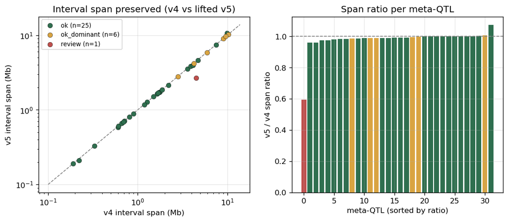

```python
cmap = {"ok":"#2f6f4f", "ok_dominant":"#d9a441", "review":"#c0504d"}
fig, ax = plt.subplots(1, 2, figsize=(11, 4.2))
for st, c in cmap.items():
    d = iv[iv.status == st]
    ax[0].scatter(d.v4_span_bp/1e6, d.v5_span_bp/1e6, c=c, s=40, edgecolor="k",
                  linewidth=0.3, label=f"{st} (n={len(d)})")
lim = [0.1, max(iv.v4_span_bp.max(), iv.v5_span_bp.max())/1e6*1.3]
ax[0].plot(lim, lim, "--", color="gray", lw=1, zorder=0)
ax[0].set_xscale("log"); ax[0].set_yscale("log")
ax[0].set_xlabel("v4 interval span (Mb)"); ax[0].set_ylabel("v5 interval span (Mb)")
ax[0].set_title("Interval span preserved (v4 vs lifted v5)"); ax[0].legend(fontsize=8)

d = iv.sort_values("span_ratio").reset_index(drop=True)
ax[1].bar(range(len(d)), d.span_ratio, color=[cmap[s] for s in d.status])
ax[1].axhline(1.0, color="gray", ls="--", lw=1)
ax[1].set_xlabel("meta-QTL (sorted by ratio)"); ax[1].set_ylabel("v5 / v4 span ratio")
ax[1].set_title("Span ratio per meta-QTL")
savefig(fig, "lift01_concordance"); plt.show()
```

## 4. Validation

```python
pts = []
for r in bed.itertuples(index=False):
    pts.append((r.chr, r.start, r.start+1, f"{r.MQTL}__s"))   # 1-bp start
    pts.append((r.chr, r.end-1, r.end,     f"{r.MQTL}__e"))   # 1-bp end
pd.DataFrame(pts).to_csv(WORK/"ends_v4.bed", sep="\t", header=False, index=False)
crossmap_bed(CHAIN45, WORK/"ends_v4.bed", WORK/"ends_v5.bed")

lifted = defaultdict(dict)
for l in open(WORK/"ends_v5.bed"):
    p = l.rstrip("\n").split("\t")           # strip newline so the tag parses cleanly
    name, w = p[3].rsplit("__", 1); lifted[name][w] = (p[0], int(p[1])+1)
identical = differ = gap = 0
for mqtl in bed.MQTL:
    d = lifted.get(mqtl, {})
    if "s" not in d or "e" not in d: gap += 1; continue           # an endpoint landed in a gap
    blk = iv.loc[iv.MQTL==mqtl].iloc[0]
    lo, hi = sorted([d["s"][1], d["e"][1]])
    if d["s"][0]==d["e"][0]==blk.v5_chr and abs(lo-blk.v5_start)<2000 and abs(hi-blk.v5_end)<2000:
        identical += 1                                            # both methods agree
    else:
        differ += 1                                               # mappable but disagree = rearrangement
print(f"{len(bed)} meta-QTLs — endpoint-lift vs block-collapse: identical {identical}, "
      f"differ {differ} (rearrangement), endpoint-in-gap {gap} (recovered only by block-collapse).")
```

```
CrossMap bed B73_RefGen_v4_to_Zm-B73-REFERENCE-NAM-5.0.chain -> ends_v5.bed
```

```
32 meta-QTLs — endpoint-lift vs block-collapse: identical 28, differ 2 (rearrangement), endpoint-in-gap 2 (recovered only by block-collapse).
```

**(b) Reverse lift (v5 → v4) of the GWAS SNPs.** As an independent check of the chain in the other direction, the study's own significant SNPs (v5) are lifted down to v4.

```python
snp_bed = LIFT/"io"/"candidates_v5.bed"
if snp_bed.exists():
    crossmap_bed(CHAIN54, snp_bed, WORK/"candidates_v4.bed")
    n_in  = sum(1 for _ in open(snp_bed))
    n_out = sum(1 for _ in open(WORK/"candidates_v4.bed"))
    print(f"v5 -> v4 SNP lift: {n_out}/{n_in} mapped")
else:
    print("candidate SNP BED not present; skipping reverse-lift demonstration")
```

```
CrossMap bed Zm-B73-REFERENCE-NAM-5.0_to_B73_RefGen_v4.chain -> candidates_v4.bed
```

```
v5 -> v4 SNP lift: 518/518 mapped
```

## Summary

The resulting v5 meta-QTL intervals are what the model-prioritized loci are intersected against.